# Module 112

#### Contrast SVE:

Signed variance explained (SVE) provides an indication of how similar a set of fold changes are to a gene module’s weight vector. An SVE value of 0.3, for example, indicates that 30% of the variance explained by the entire module set is accounted for by the module in question. Shown here are the SVE values for this module across a compendium of fold changes (contrasts). Extreme SVE values (e.g., > 0.05) indicate that those contrasts specifically induce (orange dots) or specifically repress (blue dots) this module. Examining the experimental conditions being compared in such contrasts (see tables below the figure) may provide insight into the gene module’s function.

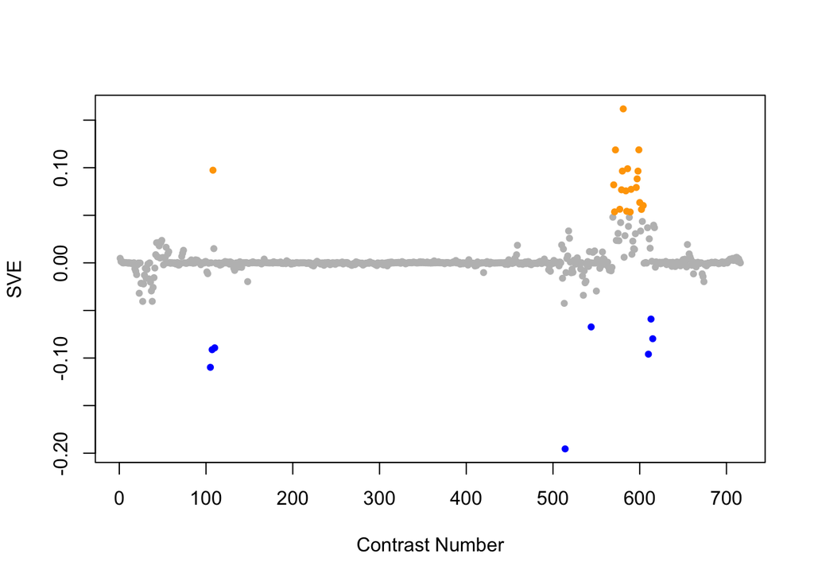

Positive SVE Contrasts:

|  | Contrast.Num | SVE | GEO.GSE | Cond.1 | Cond.2 | Mutation |
| --- | --- | --- | --- | --- | --- | --- |
| GSE2180.s2t10.vs.s2t1 | 581 | 0.16 | GSE2180 | ms186-5 | ms0-1 |  |
| GSE2180.s4t10.vs.s4t1 | 599 | 0.12 | GSE2180 | pp186-1 | pp0-1 |  |
| GSE2180.s1t10.vs.s1t1 | 572 | 0.12 | GSE2180 | 186-1 | 00B |  |
| GSE2180.s2t6.vs.s2t1 | 586 | 0.10 | GSE2180 | ms83-5 | ms0-1 |  |
| GSE54513.s3t1.vs.s2t1 | 108 | 0.10 | GSE54513 | spe-9 input rep1 | fog-1 OMA-1 IP rep1 |  |
| GSE2180.s2t9.vs.s2t1 | 580 | 0.10 | GSE2180 | ms143-2 | ms0-1 |  |
| GSE2180.s4t9.vs.s4t1 | 598 | 0.10 | GSE2180 | pp143-1 | pp0-1 |  |
| GSE2180.s4t8.vs.s4t1 | 597 | 0.09 | GSE2180 | pp122-1 | pp0-1 |  |
| GSE2180.s1t8.vs.s1t1 | 570 | 0.08 | GSE2180 | 122-1 | 00B |  |
| GSE2180.s4t7.vs.s4t1 | 596 | 0.08 | GSE2180 | pp101-1 | pp0-1 |  |
| GSE2180.s3t10.vs.s3t1 | 590 | 0.08 | GSE2180 | p186-2 | p0-3 |  |
| GSE2180.s2t8.vs.s2t1 | 579 | 0.08 | GSE2180 | ms122-1 | ms0-1 |  |
| GSE2180.s2t4.vs.s2t1 | 584 | 0.08 | GSE2180 | ms53-4 | ms0-1 |  |
| GSE2180.s4t2.vs.s4t1 | 600 | 0.06 | GSE2180 | pp23-1 | pp0-1 |  |
| GSE2180.s4t6.vs.s4t1 | 604 | 0.06 | GSE2180 | pp83-1 | pp0-1 |  |
| GSE2180.s1t6.vs.s1t1 | 577 | 0.06 | GSE2180 | 83-1 | 00B |  |
| GSE2180.s4t4.vs.s4t1 | 602 | 0.06 | GSE2180 | pp53-1 | pp0-1 |  |
| GSE2180.s2t5.vs.s2t1 | 585 | 0.05 | GSE2180 | ms66-3 | ms0-1 |  |
| GSE2180.s1t9.vs.s1t1 | 571 | 0.05 | GSE2180 | 143L | 00B |  |
| GSE2180.s3t9.vs.s3t1 | 589 | 0.05 | GSE2180 | p143-2 | p0-3 |  |

Negative SVE Contrasts:

|  | Contrast.Num | SVE | GEO.GSE | Cond.1 | Cond.2 | Mutation |
| --- | --- | --- | --- | --- | --- | --- |
| GSE2180.s4t1.vs.s3t1 | 514 | -0.20 | GSE2180 | pp0-1 | p0-3 | pal-1(RNAi) |
| GSE54513.s2t1.vs.s1t1 | 105 | -0.11 | GSE54513 | fog-1 OMA-1 IP rep1 | fog-1 input rep1 |  |
| GSE21591.s3t1.vs.s5t1 | 610 | -0.10 | GSE21591 | GGF_aFLAG_1 | aFLAG_1 |  |
| GSE54513.s4t1.vs.s1t1 | 107 | -0.09 | GSE54513 | spe-9 OMA-1 IP rep1 | fog-1 input rep1 |  |
| GSE54513.s4t1.vs.s3t1 | 110 | -0.09 | GSE54513 | spe-9 OMA-1 IP rep1 | spe-9 input rep1 |  |
| GSE21591.s1t1.vs.s4t1 | 615 | -0.08 | GSE21591 | N2_aFLAG_1 | aMYC_1 |  |
| GSE2180.s4t2.vs.s3t2 | 544 | -0.07 | GSE2180 | pp23-1 | p23-2 | pal-1(RNAi) |
| GSE21591.s3t1.vs.s4t1 | 613 | -0.06 | GSE21591 | GGF_aFLAG_1 | aMYC_1 |  |

$~$

#### Contrast SVE, Up-Regulated Genes Only:

Calculating SVE for up-regulated and down-regulated genes separately may be more informative in many cases than projecting the up- and down- gene sets together. This is due to the fact that the weight distribution of many modules is highly skewed, indicating that only one of the hemi-modules may be biologically meaningful (i.e., a set of genes are strongly correlated by only a few genes (or none) are strongly anti-correlated to that set.)

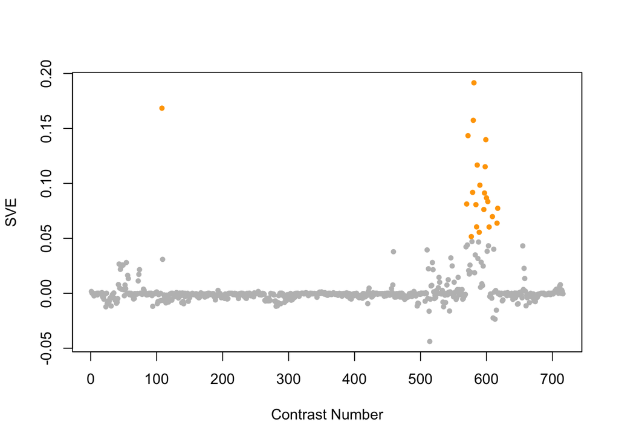

Positive SVE Contrasts:

|  | Contrast.Num | SVE | GEO.GSE | Cond.1 | Cond.2 | Mutation |
| --- | --- | --- | --- | --- | --- | --- |
| GSE2180.s2t10.vs.s2t1 | 581 | 0.19 | GSE2180 | ms186-5 | ms0-1 |  |
| GSE54513.s3t1.vs.s2t1 | 108 | 0.17 | GSE54513 | spe-9 input rep1 | fog-1 OMA-1 IP rep1 |  |
| GSE2180.s2t9.vs.s2t1 | 580 | 0.16 | GSE2180 | ms143-2 | ms0-1 |  |
| GSE2180.s1t10.vs.s1t1 | 572 | 0.14 | GSE2180 | 186-1 | 00B |  |
| GSE2180.s4t10.vs.s4t1 | 599 | 0.14 | GSE2180 | pp186-1 | pp0-1 |  |
| GSE2180.s2t6.vs.s2t1 | 586 | 0.12 | GSE2180 | ms83-5 | ms0-1 |  |
| GSE2180.s4t9.vs.s4t1 | 598 | 0.12 | GSE2180 | pp143-1 | pp0-1 |  |
| GSE2180.s3t10.vs.s3t1 | 590 | 0.10 | GSE2180 | p186-2 | p0-3 |  |
| GSE2180.s2t8.vs.s2t1 | 579 | 0.09 | GSE2180 | ms122-1 | ms0-1 |  |
| GSE2180.s4t8.vs.s4t1 | 597 | 0.09 | GSE2180 | pp122-1 | pp0-1 |  |
| GSE2180.s4t2.vs.s4t1 | 600 | 0.09 | GSE2180 | pp23-1 | pp0-1 |  |
| GSE2180.s4t4.vs.s4t1 | 602 | 0.08 | GSE2180 | pp53-1 | pp0-1 |  |
| GSE2180.s1t8.vs.s1t1 | 570 | 0.08 | GSE2180 | 122-1 | 00B |  |
| GSE2180.s2t4.vs.s2t1 | 584 | 0.08 | GSE2180 | ms53-4 | ms0-1 |  |
| GSE21591.s1t1.vs.s3t1 | 617 | 0.08 | GSE21591 | N2_aFLAG_1 | GGF_aFLAG_1 |  |
| GSE2180.s4t7.vs.s4t1 | 596 | 0.08 | GSE2180 | pp101-1 | pp0-1 |  |
| GSE21591.s4t1.vs.s5t1 | 609 | 0.07 | GSE21591 | aMYC_1 | aFLAG_1 |  |
| GSE21591.s2t1.vs.s3t1 | 616 | 0.06 | GSE21591 | Input_1 | GGF_aFLAG_1 |  |
| GSE2180.s2t5.vs.s2t1 | 585 | 0.06 | GSE2180 | ms66-3 | ms0-1 |  |
| GSE2180.s4t6.vs.s4t1 | 604 | 0.06 | GSE2180 | pp83-1 | pp0-1 |  |
| GSE2180.s3t9.vs.s3t1 | 589 | 0.06 | GSE2180 | p143-2 | p0-3 |  |
| GSE2180.s1t6.vs.s1t1 | 577 | 0.05 | GSE2180 | 83-1 | 00B |  |

Negative SVE Contrasts:

|  | Contrast.Num | SVE | GEO.GSE | Cond.1 | Cond.2 | Mutation |
| --- | --- | --- | --- | --- | --- | --- |
| GSE2180.s4t1.vs.s3t1 | 514 | -0.04 | GSE2180 | pp0-1 | p0-3 | pal-1(RNAi) |
| GSE21591.s3t1.vs.s4t1 | 613 | -0.02 | GSE21591 | GGF_aFLAG_1 | aMYC_1 |  |
| GSE21591.s3t1.vs.s5t1 | 610 | -0.02 | GSE21591 | GGF_aFLAG_1 | aFLAG_1 |  |
| GSE2180.s4t1.vs.s2t1 | 513 | -0.02 | GSE2180 | pp0-1 | ms0-1 |  |
| GSE2180.s4t2.vs.s3t2 | 544 | -0.02 | GSE2180 | pp23-1 | p23-2 | pal-1(RNAi) |

$~$

#### Contrast SVE, Down-Regulated Genes Only:

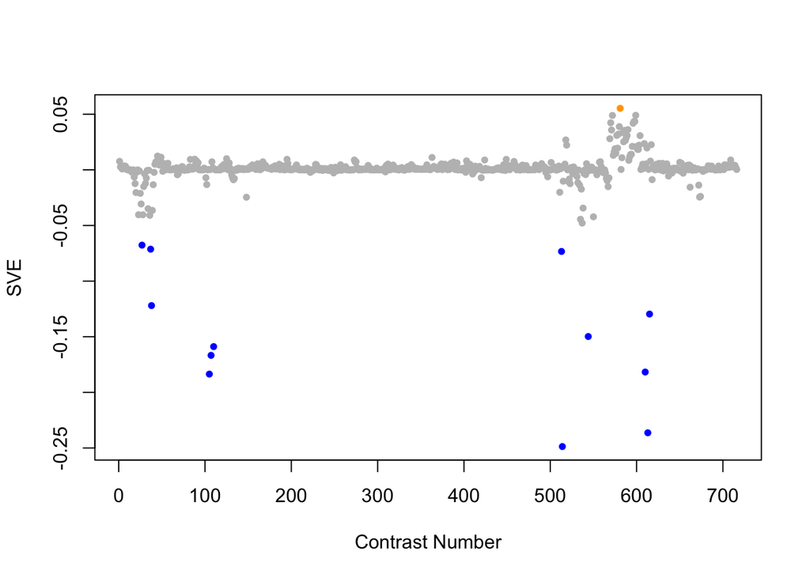

Positive SVE Contrasts:

|  | Contrast.Num | SVE | GEO.GSE | Cond.1 | Cond.2 | Mutation |
| --- | --- | --- | --- | --- | --- | --- |
| GSE2180.s2t10.vs.s2t1 | 581 | 0.06 | GSE2180 | ms186-5 | ms0-1 |  |
| GSE2180.s4t10.vs.s4t1 | 599 | 0.05 | GSE2180 | pp186-1 | pp0-1 |  |
| GSE2180.s1t10.vs.s1t1 | 572 | 0.05 | GSE2180 | 186-1 | 00B |  |
| GSE2180.s4t9.vs.s4t1 | 598 | 0.04 | GSE2180 | pp143-1 | pp0-1 |  |
| GSE2180.s4t8.vs.s4t1 | 597 | 0.04 | GSE2180 | pp122-1 | pp0-1 |  |

Negative SVE Contrasts:

|  | Contrast.Num | SVE | GEO.GSE | Cond.1 | Cond.2 | Mutation |
| --- | --- | --- | --- | --- | --- | --- |
| GSE2180.s4t1.vs.s3t1 | 514 | -0.25 | GSE2180 | pp0-1 | p0-3 | pal-1(RNAi) |
| GSE21591.s3t1.vs.s4t1 | 613 | -0.24 | GSE21591 | GGF_aFLAG_1 | aMYC_1 |  |
| GSE54513.s2t1.vs.s1t1 | 105 | -0.18 | GSE54513 | fog-1 OMA-1 IP rep1 | fog-1 input rep1 |  |
| GSE21591.s3t1.vs.s5t1 | 610 | -0.18 | GSE21591 | GGF_aFLAG_1 | aFLAG_1 |  |
| GSE54513.s4t1.vs.s1t1 | 107 | -0.17 | GSE54513 | spe-9 OMA-1 IP rep1 | fog-1 input rep1 |  |
| GSE54513.s4t1.vs.s3t1 | 110 | -0.16 | GSE54513 | spe-9 OMA-1 IP rep1 | spe-9 input rep1 |  |
| GSE2180.s4t2.vs.s3t2 | 544 | -0.15 | GSE2180 | pp23-1 | p23-2 | pal-1(RNAi) |
| GSE21591.s1t1.vs.s4t1 | 615 | -0.13 | GSE21591 | N2_aFLAG_1 | aMYC_1 |  |
| GSE9665.s7t3.vs.s0t3 | 38 | -0.12 | GSE9665 | mex-3 nob-1 230 A | mex-3 230 A | nob-1 |
| GSE2180.s4t1.vs.s2t1 | 513 | -0.07 | GSE2180 | pp0-1 | ms0-1 |  |
| GSE9665.s6t3.vs.s0t3 | 37 | -0.07 | GSE9665 | mex-3 nhr-25 230 A | mex-3 230 A | nhr-25 |
| GSE9665.s6t2.vs.s0t2 | 27 | -0.07 | GSE9665 | mex-3 nhr-25 186 A | mex-3 186 A | nhr-25 |

$~$

$~$

#### GO Term Enrichment:

This analysis tests each hemi-module for enrichment of specific GO terms. Only gene-level annotations (e.g., as would be found on the gene’s page in Wormbase) are tested - the hierarchical structure of the GO ontology is not taken into account.

*Note: At least the top two most enriched terms from each GO domain (BP/MF/CC) are shown, even when not statistically significant.*

##### Enriched GO terms: Hemi-module A

| ID | GO.Term | GO Domain | Raw p-value | Adj p-value |
| --- | --- | --- | --- | --- |
| [GO_0006412](http://amigo.geneontology.org/amigo/term/GO:0006412) | translation | BP | 1.68e-106 | 6.12e-103 |
| [GO_0002181](http://amigo.geneontology.org/amigo/term/GO:0002181) | cytoplasmic translation | BP | 1.59e-28 | 2.89e-25 |
| [GO_0000027](http://amigo.geneontology.org/amigo/term/GO:0000027) | ribosomal large subunit assembly | BP | 2.41e-18 | 2.93e-15 |
| [GO_0000028](http://amigo.geneontology.org/amigo/term/GO:0000028) | ribosomal small subunit assembly | BP | 2.30e-13 | 2.09e-10 |
| [GO_0006414](http://amigo.geneontology.org/amigo/term/GO:0006414) | translational elongation | BP | 1.55e-08 | 1.13e-05 |
| [GO_0008340](http://amigo.geneontology.org/amigo/term/GO:0008340) | determination of adult lifespan | BP | 2.12e-06 | 1.29e-03 |
| [GO_0042273](http://amigo.geneontology.org/amigo/term/GO:0042273) | ribosomal large subunit biogenesis | BP | 4.87e-05 | 2.53e-02 |
| [GO_0000470](http://amigo.geneontology.org/amigo/term/GO:0000470) | maturation of LSU-rRNA | BP | 1.02e-04 | 4.63e-02 |
| [GO_0006123](http://amigo.geneontology.org/amigo/term/GO:0006123) | mitochondrial electron transport, cytochrome c to oxygen | BP | 2.14e-04 | 8.65e-02 |
| [GO_0003735](http://amigo.geneontology.org/amigo/term/GO:0003735) | structural constituent of ribosome | MF | 1.35e-125 | 2.75e-122 |
| [GO_0003723](http://amigo.geneontology.org/amigo/term/GO:0003723) | RNA binding | MF | 1.83e-18 | 1.87e-15 |
| [GO_0019843](http://amigo.geneontology.org/amigo/term/GO:0019843) | rRNA binding | MF | 2.47e-16 | 1.68e-13 |
| [GO_0003746](http://amigo.geneontology.org/amigo/term/GO:0003746) | translation elongation factor activity | MF | 2.45e-08 | 1.25e-05 |
| [GO_0003729](http://amigo.geneontology.org/amigo/term/GO:0003729) | mRNA binding | MF | 2.65e-06 | 1.08e-03 |
| [GO_0070180](http://amigo.geneontology.org/amigo/term/GO:0070180) | large ribosomal subunit rRNA binding | MF | 7.53e-06 | 2.56e-03 |
| [GO_0004129](http://amigo.geneontology.org/amigo/term/GO:0004129) | cytochrome-c oxidase activity | MF | 1.02e-04 | 2.96e-02 |
| [GO_0005840](http://amigo.geneontology.org/amigo/term/GO:0005840) | ribosome | CC | 2.88e-125 | 2.67e-122 |
| [GO_0022625](http://amigo.geneontology.org/amigo/term/GO:0022625) | cytosolic large ribosomal subunit | CC | 7.69e-84 | 3.57e-81 |
| [GO_0022627](http://amigo.geneontology.org/amigo/term/GO:0022627) | cytosolic small ribosomal subunit | CC | 1.65e-53 | 5.09e-51 |
| [GO_0016021](http://amigo.geneontology.org/amigo/term/GO:0016021) | integral component of membrane | CC | 8.11e-22 | 1.88e-19 |
| [GO_0016020](http://amigo.geneontology.org/amigo/term/GO:0016020) | membrane | CC | 2.56e-21 | 4.75e-19 |
| [GO_0015935](http://amigo.geneontology.org/amigo/term/GO:0015935) | small ribosomal subunit | CC | 2.13e-14 | 3.30e-12 |
| [GO_0005791](http://amigo.geneontology.org/amigo/term/GO:0005791) | rough endoplasmic reticulum | CC | 6.85e-10 | 9.07e-08 |
| [GO_0015934](http://amigo.geneontology.org/amigo/term/GO:0015934) | large ribosomal subunit | CC | 2.95e-09 | 3.42e-07 |
| [GO_0042788](http://amigo.geneontology.org/amigo/term/GO:0042788) | polysomal ribosome | CC | 1.15e-07 | 1.19e-05 |
| [GO_0098556](http://amigo.geneontology.org/amigo/term/GO:0098556) | cytoplasmic side of rough endoplasmic reticulum membrane | CC | 1.90e-06 | 1.76e-04 |
| [GO_0005829](http://amigo.geneontology.org/amigo/term/GO:0005829) | cytosol | CC | 4.44e-06 | 3.74e-04 |
| [GO_0005854](http://amigo.geneontology.org/amigo/term/GO:0005854) | nascent polypeptide-associated complex | CC | 1.54e-04 | 1.19e-02 |
| [GO_0005737](http://amigo.geneontology.org/amigo/term/GO:0005737) | cytoplasm | CC | 1.83e-04 | 1.31e-02 |
| [GO_0005887](http://amigo.geneontology.org/amigo/term/GO:0005887) | integral component of plasma membrane | CC | 1.37e-03 | 9.10e-02 |
| [GO_1990904](http://amigo.geneontology.org/amigo/term/GO:1990904) | ribonucleoprotein complex | CC | 1.50e-03 | 9.26e-02 |
| [GO_0005730](http://amigo.geneontology.org/amigo/term/GO:0005730) | nucleolus | CC | 1.62e-03 | 9.41e-02 |

##### Enriched GO terms: Hemi-module B

| ID | GO.Term | GO Domain | Raw p-value | Adj p-value |
| --- | --- | --- | --- | --- |
| [GO_0045899](http://amigo.geneontology.org/amigo/term/GO:0045899) | positive regulation of RNA polymerase II transcriptional preinitiation complex assembly | BP | 7.79e-05 | 2.84e-01 |
| [GO_0030511](http://amigo.geneontology.org/amigo/term/GO:0030511) | positive regulation of transforming growth factor beta receptor signaling pathway | BP | 2.32e-04 | 4.23e-01 |
| [GO_0005515](http://amigo.geneontology.org/amigo/term/GO:0005515) | protein binding | MF | 2.26e-03 | 5.20e-01 |
| [GO_0001181](http://amigo.geneontology.org/amigo/term/GO:0001181) | RNA polymerase I general transcription initiation factor activity | MF | 2.33e-03 | 5.20e-01 |
| [GO_0000502](http://amigo.geneontology.org/amigo/term/GO:0000502) | proteasome complex | CC | 6.44e-05 | 5.97e-02 |
| [GO_0008540](http://amigo.geneontology.org/amigo/term/GO:0008540) | proteasome regulatory particle, base subcomplex | CC | 3.40e-04 | 1.58e-01 |

$~$

$~$

#### Tissue Enrichment:

This analysis tests each hemi-module for enrichment of genes associated with anatomy terms. Negative enrichment scores indicate fewer hemi-module genes than expected by random chance were associated with the anatomy term in question.

##### Enriched tissues: Hemi-module A

| ID | Anatomy.Term | Definition | Raw p-value | Adj p-value |
| --- | --- | --- | --- | --- |
| [WBbt_0003681](https://wormbase.org/species/all/anatomy_term/WBbt:0003681) | pharynx | the feeding organ, a neuro-muscular pump in the head of the animal, used to ingest food, bacteria suspended in liquid, filter them out, grind them up and transport posteriorly into the instestine. | 1.54e-12 | 3.75e-09 |
| [WBbt_0005812](https://wormbase.org/species/all/anatomy_term/WBbt:0005812) | excretory cell | H-shaped cell associated with the excretory system, largest cell in C. elegans. | 6.86e-11 | 8.35e-08 |
| [WBbt_0005813](https://wormbase.org/species/all/anatomy_term/WBbt:0005813) | body wall musculature | Longitudinal bands of muscle cells surrounding animal body, with one band running in each quadrant of the body, regulated contraction and relaxation of these muscles cause locomotion. | 1.12e-09 | 9.10e-07 |
| [WBbt_0005772](https://wormbase.org/species/all/anatomy_term/WBbt:0005772) | intestine | A chain of very large cuboidal cells forming a wide central lumen in which food arrives from the posterior pharynx, is digested, and from which waste products proceed to the rectum. Intestinal rings f… | 1.50e-06 | 9.12e-04 |
| [WBbt_0005747](https://wormbase.org/species/all/anatomy_term/WBbt:0005747) | reproductive system |  | 1.10e-05 | 5.37e-03 |
| [WBbt_0005733](https://wormbase.org/species/all/anatomy_term/WBbt:0005733) | hypodermis | Epidermal layer. | 2.52e-05 | 1.02e-02 |
| [WBbt_0004292](https://wormbase.org/species/all/anatomy_term/WBbt:0004292) | anal depressor muscle | a single, H-shaped cell which lies just above the anus and connects the roof of the anal canal to the dorsal bodywall; its contractions act to increase the size of the anal opening by lifting the roof… | 1.00e-04 | 3.48e-02 |

##### Enriched tissues: Hemi-module B

No significant annotations.

$~$

$~$

#### HOMER promoter motif enrichment:

This analysis tests each hemi-module for enrichment of 108 known *C. elegans* transcription factor binding site motifs (see [108 CE motifs](https://katiepod.github.io//all.worm.motifs.html)) using the HOMER (Hypergeometric Optimization of Motif EnRichment) software (see [PMID:20513432](https://pubmed.ncbi.nlm.nih.gov/20513432)). HOMER was run using default parameters on sequences 1 kb upstream of the transcription start site.

##### Motif enrichment: Hemi-module A

Total target sequences = 157  
Total background sequences = 35915  
* - possible false positive

Rank

Motif

P-value

log P-pvalue

% of Targets

% of Background

STD(Bg STD)

Best Match/Details

Motif File

1

[figure not shown]

1e-27

-6.392e+01

43.31%

9.46%

222.3bp (351.3bp)

MF0008.1_MADS_class/Jaspar(0.527)  
[More Information](https://katiepod.github.io/HomerResults/m112_a_hemi_genes.txt.out.1kb/homerResults/motif1.info.html) | [Similar Motifs Found](https://katiepod.github.io/HomerResults/m112_a_hemi_genes.txt.out.1kb/homerResults/motif1.similar.html)

[motif file (matrix)](https://katiepod.github.io/HomerResults/m112_a_hemi_genes.txt.out.1kb/homerResults/motif1.motif)

2

[figure not shown]

1e-25

-5.902e+01

29.30%

4.06%

110.8bp (371.9bp)

POL011.1_XCPE1/Jaspar(0.590)  
[More Information](https://katiepod.github.io/HomerResults/m112_a_hemi_genes.txt.out.1kb/homerResults/motif2.info.html) | [Similar Motifs Found](https://katiepod.github.io/HomerResults/m112_a_hemi_genes.txt.out.1kb/homerResults/motif2.similar.html)

[motif file (matrix)](https://katiepod.github.io/HomerResults/m112_a_hemi_genes.txt.out.1kb/homerResults/motif2.motif)

3

[figure not shown]

1e-22

-5.230e+01

11.46%

0.26%

119.2bp (323.3bp)

PL0018.1_hlh-25/Jaspar(0.520)  
[More Information](https://katiepod.github.io/HomerResults/m112_a_hemi_genes.txt.out.1kb/homerResults/motif3.info.html) | [Similar Motifs Found](https://katiepod.github.io/HomerResults/m112_a_hemi_genes.txt.out.1kb/homerResults/motif3.similar.html)

[motif file (matrix)](https://katiepod.github.io/HomerResults/m112_a_hemi_genes.txt.out.1kb/homerResults/motif3.motif)

4

[figure not shown]

1e-20

-4.669e+01

17.83%

1.56%

196.3bp (388.7bp)

POL010.1_DCE_S_III/Jaspar(0.626)  
[More Information](https://katiepod.github.io/HomerResults/m112_a_hemi_genes.txt.out.1kb/homerResults/motif4.info.html) | [Similar Motifs Found](https://katiepod.github.io/HomerResults/m112_a_hemi_genes.txt.out.1kb/homerResults/motif4.similar.html)

[motif file (matrix)](https://katiepod.github.io/HomerResults/m112_a_hemi_genes.txt.out.1kb/homerResults/motif4.motif)

5

[figure not shown]

1e-18

-4.247e+01

21.02%

2.83%

287.7bp (409.3bp)

SD0001.1_at_AC_acceptor/Jaspar(0.725)  
[More Information](https://katiepod.github.io/HomerResults/m112_a_hemi_genes.txt.out.1kb/homerResults/motif5.info.html) | [Similar Motifs Found](https://katiepod.github.io/HomerResults/m112_a_hemi_genes.txt.out.1kb/homerResults/motif5.similar.html)

[motif file (matrix)](https://katiepod.github.io/HomerResults/m112_a_hemi_genes.txt.out.1kb/homerResults/motif5.motif)

6

[figure not shown]

1e-18

-4.226e+01

29.94%

6.49%

226.4bp (377.0bp)

ceh-28/MA1445.1/Jaspar(0.579)  
[More Information](https://katiepod.github.io/HomerResults/m112_a_hemi_genes.txt.out.1kb/homerResults/motif6.info.html) | [Similar Motifs Found](https://katiepod.github.io/HomerResults/m112_a_hemi_genes.txt.out.1kb/homerResults/motif6.similar.html)

[motif file (matrix)](https://katiepod.github.io/HomerResults/m112_a_hemi_genes.txt.out.1kb/homerResults/motif6.motif)

7

[figure not shown]

1e-17

-4.008e+01

70.70%

36.48%

286.9bp (366.4bp)

ceh-28/MA1445.1/Jaspar(0.809)  
[More Information](https://katiepod.github.io/HomerResults/m112_a_hemi_genes.txt.out.1kb/homerResults/motif7.info.html) | [Similar Motifs Found](https://katiepod.github.io/HomerResults/m112_a_hemi_genes.txt.out.1kb/homerResults/motif7.similar.html)

[motif file (matrix)](https://katiepod.github.io/HomerResults/m112_a_hemi_genes.txt.out.1kb/homerResults/motif7.motif)

8

[figure not shown]

1e-14

-3.251e+01

45.22%

18.17%

276.2bp (357.6bp)

POL013.1_MED-1/Jaspar(0.580)  
[More Information](https://katiepod.github.io/HomerResults/m112_a_hemi_genes.txt.out.1kb/homerResults/motif8.info.html) | [Similar Motifs Found](https://katiepod.github.io/HomerResults/m112_a_hemi_genes.txt.out.1kb/homerResults/motif8.similar.html)

[motif file (matrix)](https://katiepod.github.io/HomerResults/m112_a_hemi_genes.txt.out.1kb/homerResults/motif8.motif)

9

[figure not shown]

1e-13

-3.013e+01

15.92%

2.35%

173.4bp (371.4bp)

PL0004.1_hlh-27/Jaspar(0.515)  
[More Information](https://katiepod.github.io/HomerResults/m112_a_hemi_genes.txt.out.1kb/homerResults/motif9.info.html) | [Similar Motifs Found](https://katiepod.github.io/HomerResults/m112_a_hemi_genes.txt.out.1kb/homerResults/motif9.similar.html)

[motif file (matrix)](https://katiepod.github.io/HomerResults/m112_a_hemi_genes.txt.out.1kb/homerResults/motif9.motif)

10

[figure not shown]

1e-13

-3.002e+01

13.38%

1.53%

243.0bp (343.2bp)

lin-14/MA0261.1/Jaspar(0.676)  
[More Information](https://katiepod.github.io/HomerResults/m112_a_hemi_genes.txt.out.1kb/homerResults/motif10.info.html) | [Similar Motifs Found](https://katiepod.github.io/HomerResults/m112_a_hemi_genes.txt.out.1kb/homerResults/motif10.similar.html)

[motif file (matrix)](https://katiepod.github.io/HomerResults/m112_a_hemi_genes.txt.out.1kb/homerResults/motif10.motif)

11

[figure not shown]

1e-12

-2.873e+01

32.48%

10.84%

269.6bp (394.5bp)

fos-1/MA1448.1/Jaspar(0.528)  
[More Information](https://katiepod.github.io/HomerResults/m112_a_hemi_genes.txt.out.1kb/homerResults/motif11.info.html) | [Similar Motifs Found](https://katiepod.github.io/HomerResults/m112_a_hemi_genes.txt.out.1kb/homerResults/motif11.similar.html)

[motif file (matrix)](https://katiepod.github.io/HomerResults/m112_a_hemi_genes.txt.out.1kb/homerResults/motif11.motif)

12

[figure not shown]

1e-12

-2.864e+01

29.30%

8.96%

277.6bp (361.8bp)

MF0002.1_bZIP_CREB/G-box-like_subclass/Jaspar(0.701)  
[More Information](https://katiepod.github.io/HomerResults/m112_a_hemi_genes.txt.out.1kb/homerResults/motif12.info.html) | [Similar Motifs Found](https://katiepod.github.io/HomerResults/m112_a_hemi_genes.txt.out.1kb/homerResults/motif12.similar.html)

[motif file (matrix)](https://katiepod.github.io/HomerResults/m112_a_hemi_genes.txt.out.1kb/homerResults/motif12.motif)

13

[figure not shown]

1e-12

-2.822e+01

14.01%

1.89%

164.8bp (351.0bp)

MF0009.1_TRP(MYB)_class/Jaspar(0.598)  
[More Information](https://katiepod.github.io/HomerResults/m112_a_hemi_genes.txt.out.1kb/homerResults/motif13.info.html) | [Similar Motifs Found](https://katiepod.github.io/HomerResults/m112_a_hemi_genes.txt.out.1kb/homerResults/motif13.similar.html)

[motif file (matrix)](https://katiepod.github.io/HomerResults/m112_a_hemi_genes.txt.out.1kb/homerResults/motif13.motif)

14

[figure not shown]

1e-12

-2.764e+01

14.65%

2.17%

261.7bp (348.0bp)

POL006.1_BREu/Jaspar(0.590)  
[More Information](https://katiepod.github.io/HomerResults/m112_a_hemi_genes.txt.out.1kb/homerResults/motif14.info.html) | [Similar Motifs Found](https://katiepod.github.io/HomerResults/m112_a_hemi_genes.txt.out.1kb/homerResults/motif14.similar.html)

[motif file (matrix)](https://katiepod.github.io/HomerResults/m112_a_hemi_genes.txt.out.1kb/homerResults/motif14.motif)

15 *

[figure not shown]

1e-10

-2.503e+01

21.02%

5.32%

255.7bp (359.4bp)

fkh-9/MA1440.1/Jaspar(0.718)  
[More Information](https://katiepod.github.io/HomerResults/m112_a_hemi_genes.txt.out.1kb/homerResults/motif15.info.html) | [Similar Motifs Found](https://katiepod.github.io/HomerResults/m112_a_hemi_genes.txt.out.1kb/homerResults/motif15.similar.html)

[motif file (matrix)](https://katiepod.github.io/HomerResults/m112_a_hemi_genes.txt.out.1kb/homerResults/motif15.motif)

16 *

[figure not shown]

1e-10

-2.468e+01

22.93%

6.38%

215.5bp (339.2bp)

ceh-38/MA1699.1/Jaspar(0.687)  
[More Information](https://katiepod.github.io/HomerResults/m112_a_hemi_genes.txt.out.1kb/homerResults/motif16.info.html) | [Similar Motifs Found](https://katiepod.github.io/HomerResults/m112_a_hemi_genes.txt.out.1kb/homerResults/motif16.similar.html)

[motif file (matrix)](https://katiepod.github.io/HomerResults/m112_a_hemi_genes.txt.out.1kb/homerResults/motif16.motif)

17 *

[figure not shown]

1e-9

-2.271e+01

9.55%

1.02%

277.9bp (380.0bp)

eor-1/MA0543.1/Jaspar(0.566)  
[More Information](https://katiepod.github.io/HomerResults/m112_a_hemi_genes.txt.out.1kb/homerResults/motif17.info.html) | [Similar Motifs Found](https://katiepod.github.io/HomerResults/m112_a_hemi_genes.txt.out.1kb/homerResults/motif17.similar.html)

[motif file (matrix)](https://katiepod.github.io/HomerResults/m112_a_hemi_genes.txt.out.1kb/homerResults/motif17.motif)

18 *

[figure not shown]

1e-9

-2.216e+01

7.01%

0.44%

193.7bp (373.4bp)

POL013.1_MED-1/Jaspar(0.645)  
[More Information](https://katiepod.github.io/HomerResults/m112_a_hemi_genes.txt.out.1kb/homerResults/motif18.info.html) | [Similar Motifs Found](https://katiepod.github.io/HomerResults/m112_a_hemi_genes.txt.out.1kb/homerResults/motif18.similar.html)

[motif file (matrix)](https://katiepod.github.io/HomerResults/m112_a_hemi_genes.txt.out.1kb/homerResults/motif18.motif)

19 *

[figure not shown]

1e-9

-2.154e+01

31.21%

12.32%

286.0bp (346.1bp)

LIN-39(Homeobox)/cElegans.L3-LIN39-ChIP-Seq(modEncode)/Homer(0.660)  
[More Information](https://katiepod.github.io/HomerResults/m112_a_hemi_genes.txt.out.1kb/homerResults/motif19.info.html) | [Similar Motifs Found](https://katiepod.github.io/HomerResults/m112_a_hemi_genes.txt.out.1kb/homerResults/motif19.similar.html)

[motif file (matrix)](https://katiepod.github.io/HomerResults/m112_a_hemi_genes.txt.out.1kb/homerResults/motif19.motif)

20 *

[figure not shown]

1e-9

-2.146e+01

9.55%

1.12%

299.3bp (327.8bp)

blmp-1/MA0537.1/Jaspar(0.612)  
[More Information](https://katiepod.github.io/HomerResults/m112_a_hemi_genes.txt.out.1kb/homerResults/motif20.info.html) | [Similar Motifs Found](https://katiepod.github.io/HomerResults/m112_a_hemi_genes.txt.out.1kb/homerResults/motif20.similar.html)

[motif file (matrix)](https://katiepod.github.io/HomerResults/m112_a_hemi_genes.txt.out.1kb/homerResults/motif20.motif)

21 *

[figure not shown]

1e-9

-2.141e+01

7.64%

0.61%

221.7bp (354.7bp)

POL008.1_DCE_S_I/Jaspar(0.566)  
[More Information](https://katiepod.github.io/HomerResults/m112_a_hemi_genes.txt.out.1kb/homerResults/motif21.info.html) | [Similar Motifs Found](https://katiepod.github.io/HomerResults/m112_a_hemi_genes.txt.out.1kb/homerResults/motif21.similar.html)

[motif file (matrix)](https://katiepod.github.io/HomerResults/m112_a_hemi_genes.txt.out.1kb/homerResults/motif21.motif)

22 *

[figure not shown]

1e-9

-2.100e+01

33.12%

13.83%

276.8bp (370.6bp)

MF0002.1_bZIP_CREB/G-box-like_subclass/Jaspar(0.570)  
[More Information](https://katiepod.github.io/HomerResults/m112_a_hemi_genes.txt.out.1kb/homerResults/motif22.info.html) | [Similar Motifs Found](https://katiepod.github.io/HomerResults/m112_a_hemi_genes.txt.out.1kb/homerResults/motif22.similar.html)

[motif file (matrix)](https://katiepod.github.io/HomerResults/m112_a_hemi_genes.txt.out.1kb/homerResults/motif22.motif)

23 *

[figure not shown]

1e-8

-2.066e+01

27.39%

10.13%

252.1bp (380.1bp)

ceh-38/MA1699.1/Jaspar(0.653)  
[More Information](https://katiepod.github.io/HomerResults/m112_a_hemi_genes.txt.out.1kb/homerResults/motif23.info.html) | [Similar Motifs Found](https://katiepod.github.io/HomerResults/m112_a_hemi_genes.txt.out.1kb/homerResults/motif23.similar.html)

[motif file (matrix)](https://katiepod.github.io/HomerResults/m112_a_hemi_genes.txt.out.1kb/homerResults/motif23.motif)

24 *

[figure not shown]

1e-8

-2.029e+01

7.64%

0.68%

228.4bp (324.6bp)

MF0010.1_Homeobox_class/Jaspar(0.633)  
[More Information](https://katiepod.github.io/HomerResults/m112_a_hemi_genes.txt.out.1kb/homerResults/motif24.info.html) | [Similar Motifs Found](https://katiepod.github.io/HomerResults/m112_a_hemi_genes.txt.out.1kb/homerResults/motif24.similar.html)

[motif file (matrix)](https://katiepod.github.io/HomerResults/m112_a_hemi_genes.txt.out.1kb/homerResults/motif24.motif)

25 *

[figure not shown]

1e-8

-1.968e+01

11.46%

1.95%

255.9bp (323.4bp)

pal-1/MA0924.1/Jaspar(0.651)  
[More Information](https://katiepod.github.io/HomerResults/m112_a_hemi_genes.txt.out.1kb/homerResults/motif25.info.html) | [Similar Motifs Found](https://katiepod.github.io/HomerResults/m112_a_hemi_genes.txt.out.1kb/homerResults/motif25.similar.html)

[motif file (matrix)](https://katiepod.github.io/HomerResults/m112_a_hemi_genes.txt.out.1kb/homerResults/motif25.motif)

26 *

[figure not shown]

1e-8

-1.916e+01

7.64%

0.76%

274.0bp (327.7bp)

POL008.1_DCE_S_I/Jaspar(0.537)  
[More Information](https://katiepod.github.io/HomerResults/m112_a_hemi_genes.txt.out.1kb/homerResults/motif26.info.html) | [Similar Motifs Found](https://katiepod.github.io/HomerResults/m112_a_hemi_genes.txt.out.1kb/homerResults/motif26.similar.html)

[motif file (matrix)](https://katiepod.github.io/HomerResults/m112_a_hemi_genes.txt.out.1kb/homerResults/motif26.motif)

27 *

[figure not shown]

1e-8

-1.886e+01

4.46%

0.14%

338.8bp (317.1bp)

MF0011.1_HMG_class/Jaspar(0.685)  
[More Information](https://katiepod.github.io/HomerResults/m112_a_hemi_genes.txt.out.1kb/homerResults/motif27.info.html) | [Similar Motifs Found](https://katiepod.github.io/HomerResults/m112_a_hemi_genes.txt.out.1kb/homerResults/motif27.similar.html)

[motif file (matrix)](https://katiepod.github.io/HomerResults/m112_a_hemi_genes.txt.out.1kb/homerResults/motif27.motif)

28 *

[figure not shown]

1e-8

-1.868e+01

7.01%

0.62%

233.8bp (355.0bp)

cebp-1/MA1444.1/Jaspar(0.790)  
[More Information](https://katiepod.github.io/HomerResults/m112_a_hemi_genes.txt.out.1kb/homerResults/motif28.info.html) | [Similar Motifs Found](https://katiepod.github.io/HomerResults/m112_a_hemi_genes.txt.out.1kb/homerResults/motif28.similar.html)

[motif file (matrix)](https://katiepod.github.io/HomerResults/m112_a_hemi_genes.txt.out.1kb/homerResults/motif28.motif)

29 *

[figure not shown]

1e-8

-1.851e+01

8.92%

1.19%

273.3bp (334.6bp)

cebp-1/MA1444.1/Jaspar(0.557)  
[More Information](https://katiepod.github.io/HomerResults/m112_a_hemi_genes.txt.out.1kb/homerResults/motif29.info.html) | [Similar Motifs Found](https://katiepod.github.io/HomerResults/m112_a_hemi_genes.txt.out.1kb/homerResults/motif29.similar.html)

[motif file (matrix)](https://katiepod.github.io/HomerResults/m112_a_hemi_genes.txt.out.1kb/homerResults/motif29.motif)

30 *

[figure not shown]

1e-7

-1.768e+01

11.46%

2.23%

328.7bp (349.2bp)

blmp-1/MA0537.1/Jaspar(0.546)  
[More Information](https://katiepod.github.io/HomerResults/m112_a_hemi_genes.txt.out.1kb/homerResults/motif30.info.html) | [Similar Motifs Found](https://katiepod.github.io/HomerResults/m112_a_hemi_genes.txt.out.1kb/homerResults/motif30.similar.html)

[motif file (matrix)](https://katiepod.github.io/HomerResults/m112_a_hemi_genes.txt.out.1kb/homerResults/motif30.motif)

31 *

[figure not shown]

1e-7

-1.667e+01

8.92%

1.38%

334.9bp (302.4bp)

ces-2/MA0922.1/Jaspar(0.703)  
[More Information](https://katiepod.github.io/HomerResults/m112_a_hemi_genes.txt.out.1kb/homerResults/motif31.info.html) | [Similar Motifs Found](https://katiepod.github.io/HomerResults/m112_a_hemi_genes.txt.out.1kb/homerResults/motif31.similar.html)

[motif file (matrix)](https://katiepod.github.io/HomerResults/m112_a_hemi_genes.txt.out.1kb/homerResults/motif31.motif)

32 *

[figure not shown]

1e-6

-1.515e+01

13.38%

3.58%

250.6bp (358.2bp)

MF0002.1_bZIP_CREB/G-box-like_subclass/Jaspar(0.729)  
[More Information](https://katiepod.github.io/HomerResults/m112_a_hemi_genes.txt.out.1kb/homerResults/motif32.info.html) | [Similar Motifs Found](https://katiepod.github.io/HomerResults/m112_a_hemi_genes.txt.out.1kb/homerResults/motif32.similar.html)

[motif file (matrix)](https://katiepod.github.io/HomerResults/m112_a_hemi_genes.txt.out.1kb/homerResults/motif32.motif)

33 *

[figure not shown]

1e-5

-1.203e+01

31.21%

16.71%

297.5bp (341.9bp)

fkh-2/MA0920.1/Jaspar(0.670)  
[More Information](https://katiepod.github.io/HomerResults/m112_a_hemi_genes.txt.out.1kb/homerResults/motif33.info.html) | [Similar Motifs Found](https://katiepod.github.io/HomerResults/m112_a_hemi_genes.txt.out.1kb/homerResults/motif33.similar.html)

[motif file (matrix)](https://katiepod.github.io/HomerResults/m112_a_hemi_genes.txt.out.1kb/homerResults/motif33.motif)

34 *

[figure not shown]

1e-2

-5.437e+00

0.64%

0.00%

95.8bp (0.0bp)

MF0008.1_MADS_class/Jaspar(0.636)  
[More Information](https://katiepod.github.io/HomerResults/m112_a_hemi_genes.txt.out.1kb/homerResults/motif34.info.html) | [Similar Motifs Found](https://katiepod.github.io/HomerResults/m112_a_hemi_genes.txt.out.1kb/homerResults/motif34.similar.html)

[motif file (matrix)](https://katiepod.github.io/HomerResults/m112_a_hemi_genes.txt.out.1kb/homerResults/motif34.motif)

##### Motif enrichment: Hemi-module B

Total target sequences = 28  
Total background sequences = 35149  
* - possible false positive

Rank

Motif

P-value

log P-pvalue

% of Targets

% of Background

STD(Bg STD)

Best Match/Details

Motif File

1 *

[figure not shown]

1e-9

-2.169e+01

32.14%

1.60%

289.6bp (322.1bp)

MF0009.1_TRP(MYB)_class/Jaspar(0.525)  
[More Information](https://katiepod.github.io/HomerResults/m112_b_hemi_genes.txt.out.1kb/homerResults/motif1.info.html) | [Similar Motifs Found](https://katiepod.github.io/HomerResults/m112_b_hemi_genes.txt.out.1kb/homerResults/motif1.similar.html)

[motif file (matrix)](https://katiepod.github.io/HomerResults/m112_b_hemi_genes.txt.out.1kb/homerResults/motif1.motif)

2 *

[figure not shown]

1e-8

-1.976e+01

28.57%

1.34%

277.7bp (309.7bp)

MF0011.1_HMG_class/Jaspar(0.593)  
[More Information](https://katiepod.github.io/HomerResults/m112_b_hemi_genes.txt.out.1kb/homerResults/motif2.info.html) | [Similar Motifs Found](https://katiepod.github.io/HomerResults/m112_b_hemi_genes.txt.out.1kb/homerResults/motif2.similar.html)

[motif file (matrix)](https://katiepod.github.io/HomerResults/m112_b_hemi_genes.txt.out.1kb/homerResults/motif2.motif)

3 *

[figure not shown]

1e-8

-1.905e+01

17.86%

0.22%

233.6bp (461.5bp)

dpy-27/MA0540.1/Jaspar(0.547)  
[More Information](https://katiepod.github.io/HomerResults/m112_b_hemi_genes.txt.out.1kb/homerResults/motif3.info.html) | [Similar Motifs Found](https://katiepod.github.io/HomerResults/m112_b_hemi_genes.txt.out.1kb/homerResults/motif3.similar.html)

[motif file (matrix)](https://katiepod.github.io/HomerResults/m112_b_hemi_genes.txt.out.1kb/homerResults/motif3.motif)

4 *

[figure not shown]

1e-8

-1.893e+01

17.86%

0.22%

233.8bp (333.1bp)

MF0011.1_HMG_class/Jaspar(0.571)  
[More Information](https://katiepod.github.io/HomerResults/m112_b_hemi_genes.txt.out.1kb/homerResults/motif4.info.html) | [Similar Motifs Found](https://katiepod.github.io/HomerResults/m112_b_hemi_genes.txt.out.1kb/homerResults/motif4.similar.html)

[motif file (matrix)](https://katiepod.github.io/HomerResults/m112_b_hemi_genes.txt.out.1kb/homerResults/motif4.motif)

5 *

[figure not shown]

1e-8

-1.883e+01

32.14%

2.23%

263.3bp (318.5bp)

lim-4/MA0923.1/Jaspar(0.525)  
[More Information](https://katiepod.github.io/HomerResults/m112_b_hemi_genes.txt.out.1kb/homerResults/motif5.info.html) | [Similar Motifs Found](https://katiepod.github.io/HomerResults/m112_b_hemi_genes.txt.out.1kb/homerResults/motif5.similar.html)

[motif file (matrix)](https://katiepod.github.io/HomerResults/m112_b_hemi_genes.txt.out.1kb/homerResults/motif5.motif)

6 *

[figure not shown]

1e-8

-1.844e+01

14.29%

0.08%

277.4bp (265.3bp)

elt-3/MA0542.1/Jaspar(0.638)  
[More Information](https://katiepod.github.io/HomerResults/m112_b_hemi_genes.txt.out.1kb/homerResults/motif6.info.html) | [Similar Motifs Found](https://katiepod.github.io/HomerResults/m112_b_hemi_genes.txt.out.1kb/homerResults/motif6.similar.html)

[motif file (matrix)](https://katiepod.github.io/HomerResults/m112_b_hemi_genes.txt.out.1kb/homerResults/motif6.motif)

7 *

[figure not shown]

1e-6

-1.572e+01

17.86%

0.43%

227.6bp (350.1bp)

POL013.1_MED-1/Jaspar(0.560)  
[More Information](https://katiepod.github.io/HomerResults/m112_b_hemi_genes.txt.out.1kb/homerResults/motif7.info.html) | [Similar Motifs Found](https://katiepod.github.io/HomerResults/m112_b_hemi_genes.txt.out.1kb/homerResults/motif7.similar.html)

[motif file (matrix)](https://katiepod.github.io/HomerResults/m112_b_hemi_genes.txt.out.1kb/homerResults/motif7.motif)

8 *

[figure not shown]

1e-5

-1.360e+01

28.57%

3.01%

248.6bp (339.4bp)

PL0001.1_hlh-11/Jaspar(0.620)  
[More Information](https://katiepod.github.io/HomerResults/m112_b_hemi_genes.txt.out.1kb/homerResults/motif8.info.html) | [Similar Motifs Found](https://katiepod.github.io/HomerResults/m112_b_hemi_genes.txt.out.1kb/homerResults/motif8.similar.html)

[motif file (matrix)](https://katiepod.github.io/HomerResults/m112_b_hemi_genes.txt.out.1kb/homerResults/motif8.motif)

9 *

[figure not shown]

1e-5

-1.334e+01

57.14%

16.82%

260.9bp (347.6bp)

MF0002.1_bZIP_CREB/G-box-like_subclass/Jaspar(0.626)  
[More Information](https://katiepod.github.io/HomerResults/m112_b_hemi_genes.txt.out.1kb/homerResults/motif9.info.html) | [Similar Motifs Found](https://katiepod.github.io/HomerResults/m112_b_hemi_genes.txt.out.1kb/homerResults/motif9.similar.html)

[motif file (matrix)](https://katiepod.github.io/HomerResults/m112_b_hemi_genes.txt.out.1kb/homerResults/motif9.motif)

10 *

[figure not shown]

1e-5

-1.179e+01

10.71%

0.13%

356.0bp (444.1bp)

PL0011.1_hlh-2::hlh-4/Jaspar(0.548)  
[More Information](https://katiepod.github.io/HomerResults/m112_b_hemi_genes.txt.out.1kb/homerResults/motif10.info.html) | [Similar Motifs Found](https://katiepod.github.io/HomerResults/m112_b_hemi_genes.txt.out.1kb/homerResults/motif10.similar.html)

[motif file (matrix)](https://katiepod.github.io/HomerResults/m112_b_hemi_genes.txt.out.1kb/homerResults/motif10.motif)

11 *

[figure not shown]

1e-4

-1.109e+01

25.00%

3.01%

275.9bp (382.5bp)

PL0005.1_hlh-30/Jaspar(0.737)  
[More Information](https://katiepod.github.io/HomerResults/m112_b_hemi_genes.txt.out.1kb/homerResults/motif11.info.html) | [Similar Motifs Found](https://katiepod.github.io/HomerResults/m112_b_hemi_genes.txt.out.1kb/homerResults/motif11.similar.html)

[motif file (matrix)](https://katiepod.github.io/HomerResults/m112_b_hemi_genes.txt.out.1kb/homerResults/motif11.motif)

12 *

[figure not shown]

1e-4

-9.348e+00

21.43%

2.69%

337.2bp (337.9bp)

EGL-5(Homeobox)/cElegans-L3-EGL5-ChIP-Seq(modEncode)/Homer(0.735)  
[More Information](https://katiepod.github.io/HomerResults/m112_b_hemi_genes.txt.out.1kb/homerResults/motif12.info.html) | [Similar Motifs Found](https://katiepod.github.io/HomerResults/m112_b_hemi_genes.txt.out.1kb/homerResults/motif12.similar.html)

[motif file (matrix)](https://katiepod.github.io/HomerResults/m112_b_hemi_genes.txt.out.1kb/homerResults/motif12.motif)

13 *

[figure not shown]

1e-3

-8.807e+00

10.71%

0.36%

185.0bp (361.3bp)

ceh-22/MA0264.1/Jaspar(0.507)  
[More Information](https://katiepod.github.io/HomerResults/m112_b_hemi_genes.txt.out.1kb/homerResults/motif13.info.html) | [Similar Motifs Found](https://katiepod.github.io/HomerResults/m112_b_hemi_genes.txt.out.1kb/homerResults/motif13.similar.html)

[motif file (matrix)](https://katiepod.github.io/HomerResults/m112_b_hemi_genes.txt.out.1kb/homerResults/motif13.motif)

14 *

[figure not shown]

1e-3

-8.424e+00

10.71%

0.41%

321.9bp (333.9bp)

fos-1/MA1448.1/Jaspar(0.538)  
[More Information](https://katiepod.github.io/HomerResults/m112_b_hemi_genes.txt.out.1kb/homerResults/motif14.info.html) | [Similar Motifs Found](https://katiepod.github.io/HomerResults/m112_b_hemi_genes.txt.out.1kb/homerResults/motif14.similar.html)

[motif file (matrix)](https://katiepod.github.io/HomerResults/m112_b_hemi_genes.txt.out.1kb/homerResults/motif14.motif)

15 *

[figure not shown]

1e-3

-8.165e+00

46.43%

16.97%

303.2bp (329.7bp)

unc-30/MA1443.1/Jaspar(0.562)  
[More Information](https://katiepod.github.io/HomerResults/m112_b_hemi_genes.txt.out.1kb/homerResults/motif15.info.html) | [Similar Motifs Found](https://katiepod.github.io/HomerResults/m112_b_hemi_genes.txt.out.1kb/homerResults/motif15.similar.html)

[motif file (matrix)](https://katiepod.github.io/HomerResults/m112_b_hemi_genes.txt.out.1kb/homerResults/motif15.motif)

16 *

[figure not shown]

1e-2

-6.041e+00

3.57%

0.01%

0.0bp (194.2bp)

MF0001.1_ETS_class/Jaspar(0.635)  
[More Information](https://katiepod.github.io/HomerResults/m112_b_hemi_genes.txt.out.1kb/homerResults/motif16.info.html) | [Similar Motifs Found](https://katiepod.github.io/HomerResults/m112_b_hemi_genes.txt.out.1kb/homerResults/motif16.similar.html)

[motif file (matrix)](https://katiepod.github.io/HomerResults/m112_b_hemi_genes.txt.out.1kb/homerResults/motif16.motif)

$~$

$~$

#### Promoter Word Enrichment:

This analysis tests each hemi-module for enrichment of specific promoter words. The list of promoter words tested was generated by running the MobyDick algorithm (see [PMID:10944202](https://pubmed.ncbi.nlm.nih.gov/10944202)) on the full set of *C. elegans* 2 Kbp promoters.

##### Enriched promoter words: Hemi-module A

| Word | RC | Raw.p.value | Adj.p.value |
| --- | --- | --- | --- |
| GGGTCTCG | CGAGACCC | 6.41e-14 | 3.35e-10 |
| GGCCTAAA | TTTAGGCC | 9.99e-13 | 2.61e-09 |
| GGTCTCG | CGAGACC | 2.83e-12 | 4.94e-09 |
| TTTTCAGGTAA | TTACCTGAAAA | 7.20e-11 | 9.41e-08 |
| GGGTCTC | GAGACCC | 9.70e-11 | 1.01e-07 |
| CTCGT | ACGAG | 3.18e-09 | 2.78e-06 |
| TTTCAGGTA | TACCTGAAA | 6.43e-09 | 4.65e-06 |
| CGATTTTT | AAAAATCG | 7.12e-09 | 4.65e-06 |
| CGGGTCTCG | CGAGACCCG | 1.29e-08 | 7.49e-06 |
| ATCGAT | ATCGAT | 3.13e-08 | 1.64e-05 |
| TCTCGC | GCGAGA | 7.28e-08 | 3.46e-05 |
| TCGCT | AGCGA | 8.40e-08 | 3.66e-05 |
| ATCGATT | AATCGAT | 1.66e-07 | 6.46e-05 |
| TTTTTCG | CGAAAAA | 1.73e-07 | 6.46e-05 |
| CGCAGCG | CGCTGCG | 2.25e-07 | 7.84e-05 |
| TCGATTTTT | AAAAATCGA | 2.55e-07 | 8.34e-05 |
| CGTCG | CGACG | 3.04e-07 | 9.35e-05 |
| GGTCTCGCAGC | GCTGCGAGACC | 3.32e-07 | 9.66e-05 |
| CAGGTA | TACCTG | 3.63e-07 | 1.00e-04 |
| GGTCTCGCA | TGCGAGACC | 3.94e-07 | 1.03e-04 |
| GTCTCG | CGAGAC | 4.37e-07 | 1.09e-04 |
| AGCGA | TCGCT | 5.01e-07 | 1.19e-04 |
| TTAAAGGCGCA | TGCGCCTTTAA | 1.03e-06 | 2.34e-04 |
| ATCGA | TCGAT | 1.22e-06 | 2.66e-04 |
| GGCCTAAAA | TTTTAGGCC | 1.41e-06 | 2.85e-04 |
| GGGTC | GACCC | 1.41e-06 | 2.85e-04 |
| GGTCTCGCCACG | CGTGGCGAGACC | 1.77e-06 | 3.43e-04 |
| CGATTTTTC | GAAAAATCG | 2.03e-06 | 3.80e-04 |
| TGGGTCTCGC | GCGAGACCCA | 2.16e-06 | 3.90e-04 |
| ACGAG | CTCGT | 2.28e-06 | 3.97e-04 |

[output cut: 127 more lines]

##### Enriched promoter words: Hemi-module B

| Word | RC | Raw.p.value | Adj.p.value |
| --- | --- | --- | --- |
| ACGGCC | GGCCGT | 5.10e-06 | 2.67e-02 |

$~$

$~$

#### Promoter Word Depletion:

This analysis tests each hemi-module for depletion (under-enrichment) of specific promoter words. The list of promoter words tested was generated by running the MobyDick algorithm (see [PMID:10944202](https://pubmed.ncbi.nlm.nih.gov/10944202)) on the full set of *C. elegans* 2 Kbp promoters.

##### Depleted promoter words: Hemi-module A

| Word | RC | Raw.p.value | Adj.p.value |
| --- | --- | --- | --- |
| AAGTTTG | CAAACTT | 5.36e-06 | 2.28e-02 |
| TGCCAA | TTGGCA | 8.72e-06 | 2.28e-02 |
| ACTAC | GTAGT | 1.31e-05 | 2.28e-02 |
| TTGCCAA | TTGGCAA | 3.20e-05 | 4.18e-02 |
| AAAGTTT | AAACTTT | 6.96e-05 | 7.28e-02 |
| CTATAAA | TTTATAG | 8.61e-05 | 7.51e-02 |
| ACCTA | TAGGT | 1.45e-04 | 8.89e-02 |
| TGCCAAA | TTTGGCA | 1.53e-04 | 8.89e-02 |
| ATTTCAA | TTGAAAT | 2.09e-04 | 8.89e-02 |
| AGTCTA | TAGACT | 2.12e-04 | 8.89e-02 |
| GTTAG | CTAAC | 2.25e-04 | 8.89e-02 |
| AATTTTGAAA | TTTCAAAATT | 2.44e-04 | 8.89e-02 |
| AACATTT | AAATGTT | 2.57e-04 | 8.89e-02 |
| AGTGCA | TGCACT | 2.65e-04 | 8.89e-02 |
| AAACTTT | AAAGTTT | 2.69e-04 | 8.89e-02 |
| AAATTTTGAA | TTCAAAATTT | 2.82e-04 | 8.89e-02 |
| CATGT | ACATG | 3.13e-04 | 8.89e-02 |
| TCTAG | CTAGA | 3.35e-04 | 8.89e-02 |
| CCTACC | GGTAGG | 3.52e-04 | 8.89e-02 |
| AATTTTGAA | TTCAAAATT | 3.60e-04 | 8.89e-02 |
| TTCAAAT | ATTTGAA | 3.62e-04 | 8.89e-02 |
| AAAGGT | ACCTTT | 3.86e-04 | 8.89e-02 |
| CTATAAAA | TTTTATAG | 4.07e-04 | 8.89e-02 |
| GACTACA | TGTAGTC | 4.28e-04 | 8.89e-02 |
| TACCATA | TATGGTA | 4.39e-04 | 8.89e-02 |
| AAAAAAG | CTTTTTT | 4.82e-04 | 8.89e-02 |
| AAACAT | ATGTTT | 4.91e-04 | 8.89e-02 |
| ACAGTTT | AAACTGT | 4.91e-04 | 8.89e-02 |
| AAATTTCAAA | TTTGAAATTT | 4.93e-04 | 8.89e-02 |
| ACATGT | ACATGT | 5.30e-04 | 9.24e-02 |
| AATCTTA | TAAGATT | 6.04e-04 | 9.99e-02 |
| ATTTCA | TGAAAT | 6.11e-04 | 9.99e-02 |

##### Depleted promoter words: Hemi-module B

No significant words.

$~$

$~$

#### 3’-UTR Word Enrichment:

This analysis tests each hemi-module for enrichment of specific 3’-UTR words. The list of words tested was generated by running the MobyDick algorithm (see [PMID:10944202](https://pubmed.ncbi.nlm.nih.gov/10944202)) on the full set of *C. elegans* 3’-UTR sequences.

##### 3’-UTR words: Hemi-module A

| Word | RC | Raw.p.value | Adj.p.value |
| --- | --- | --- | --- |
| TTGTT | AACAA | 3.54e-26 | 3.41e-23 |
| TTGT | ACAA | 4.45e-17 | 2.14e-14 |
| GTTG | CAAC | 8.71e-17 | 2.79e-14 |
| TTGTTG | CAACAA | 4.03e-16 | 9.69e-14 |
| GTTAC | GTAAC | 2.38e-12 | 4.57e-10 |
| GTTGT | ACAAC | 9.33e-11 | 1.50e-08 |
| TTG | CAA | 2.82e-10 | 3.87e-08 |
| TTGTTGTT | AACAACAA | 2.63e-09 | 3.16e-07 |
| TTTTGTTG | CAACAAAA | 7.81e-08 | 8.35e-06 |
| TTTTTGTTG | CAACAAAAA | 9.43e-07 | 9.08e-05 |

##### 3’-UTR words: Hemi-module B

No significant words.

$~$

$~$

#### Hemi-module A genes

| affy_c_elegans | ensembl_gene_id | external_gene_name | module_weight | chromosome_name | strand | start_position | end_position |
| --- | --- | --- | --- | --- | --- | --- | --- |
| 192991_s_at | WBGene00004483 | rps-14 | 14.19 | III | -1 | 7178984 | 7179606 |
| 173333_s_at | WBGene00004456 | rpl-43 | 13.60 | II | 1 | 14155280 | 14155660 |
| 173253_s_at | WBGene00004434 | rpl-22 | 13.35 | II | 1 | 5055616 | 5056214 |
| 192877_at | WBGene00004484 | rps-15 | 13.30 | I | -1 | 8815554 | 8816193 |
| 173329_s_at | WBGene00004485 | rps-16 | 13.21 | V | -1 | 15000011 | 15000594 |
| 173269_s_at | WBGene00004428 | rpl-16 | 12.39 | III | -1 | 3502841 | 3503724 |
| 173375_s_at | WBGene00004427 | rpl-15 | 12.24 | IV | -1 | 653436 | 654576 |
| 173375_s_at | WBGene00044948 | K11H12.12 | 12.24 | IV | -1 | 653902 | 654030 |
| 192990_at | WBGene00004483 | rps-14 | 12.07 | III | -1 | 7178984 | 7179606 |
| 172883_x_at | WBGene00004434 | rpl-22 | 12.06 | II | 1 | 5055616 | 5056214 |
| 173246_s_at | WBGene00004496 | rps-27 | 12.04 | V | -1 | 103394 | 104064 |
| 173351_s_at | WBGene00004449 | rpl-35 | 12.00 | III | 1 | 7855118 | 7855680 |
| 173248_s_at | WBGene00004446 | rpl-32 | 12.00 | II | -1 | 9056499 | 9057111 |
| 171954_x_at | WBGene00004480 | rps-11 | 11.84 | IV | 1 | 11602641 | 11603283 |
| 189778_s_at | WBGene00004494 | rps-25 | 11.75 | IV | -1 | 5947036 | 5947607 |
| 192687_s_at | WBGene00004492 | rps-23 | 11.75 | IV | -1 | 12390264 | 12391396 |
| 192687_s_at | WBGene00044962 | F28D1.13 | 11.75 | IV | -1 | 12390526 | 12390655 |
| 173112_s_at | WBGene00004478 | rps-9 | 11.43 | II | -1 | 11125371 | 11126362 |
| 173315_at | WBGene00021350 | Y37E3.8 | 11.39 | I | -1 | 2069681 | 2070607 |
| 173315_at | WBGene00044932 | Y37E3.22 | 11.39 | I | -1 | 2069884 | 2070023 |
| 173380_at | WBGene00004429 | rpl-17 | 11.35 | I | 1 | 1156579 | 1157474 |
| 192013_s_at | WBGene00004432 | rpl-20 | 11.31 | IV | -1 | 4749012 | 4749778 |
| 192013_s_at | WBGene00017121 | cyc-2.1 | 11.31 | IV | -1 | 4747901 | 4749113 |
| 188466_s_at | WBGene00004452 | rpl-38 | 11.29 | V | 1 | 15512166 | 15512780 |
| 190133_at | WBGene00004408 | rla-0 | 11.25 | I | 1 | 10567894 | 10569019 |
| 173331_s_at | WBGene00004450 | rpl-36 | 11.08 | III | 1 | 7180249 | 7180677 |
| 173087_s_at | WBGene00004420 | rpl-9 | 11.03 | III | -1 | 7572105 | 7572831 |
| 193286_s_at | WBGene00004447 | rpl-33 | 10.97 | II | 1 | 7105556 | 7106462 |
| 172865_x_at | WBGene00004441 | rpl-27 | 10.85 | I | 1 | 1834881 | 1835439 |
| 172865_x_at | WBGene00016907 | C53H9.2 | 10.85 | I | 1 | 1832897 | 1834764 |

[output cut: 238 more lines]

#### Hemi-module B genes

| affy_c_elegans | ensembl_gene_id | external_gene_name | module_weight | chromosome_name | strand | start_position | end_position |
| --- | --- | --- | --- | --- | --- | --- | --- |
| 173141_s_at | WBGene00003949 | pbs-3 | -3.93 | II | -1 | 4954480 | 4955427 |
| 174392_at | WBGene00004132 | ifet-1 | -3.73 | III | -1 | 4471407 | 4475150 |
| 177535_s_at | WBGene00020115 | mboa-6 | -3.67 | III | -1 | 1952014 | 1961945 |
| 173265_at | WBGene00022199 | pfk-1.1 | -3.61 | X | 1 | 2940872 | 2945481 |
| 186636_s_at | WBGene00007980 | C36E8.1 | -3.51 | III | -1 | 3999286 | 4004143 |
| 187144_at | WBGene00006739 | ulp-4 | -3.25 | II | 1 | 8129960 | 8134742 |
| 175751_s_at | WBGene00003777 | nmy-2 | -3.18 | I | -1 | 7926623 | 7934577 |
| 174140_at | WBGene00009772 | ztf-7 | -3.15 | V | -1 | 9786949 | 9789707 |
| 175118_s_at | WBGene00000378 | cct-2 | -3.09 | II | 1 | 8927741 | 8929820 |
| 179543_s_at | WBGene00044094 | fitm-2 | -3.06 | I | -1 | 8253452 | 8254961 |
| 172016_x_at | WBGene00006324 | sup-17 | -3.06 | I | 1 | 8792965 | 8797293 |
| 175315_at | WBGene00006704 | ubc-7 | -3.05 | III | -1 | 9630085 | 9631167 |
| 188424_s_at | WBGene00004504 | rpt-4 | -3.03 | II | -1 | 42181 | 46216 |
| 190773_s_at | WBGene00006638 | tsp-12 | -3.01 | IV | -1 | 10149166 | 10150602 |
| 192241_at | WBGene00012015 | T25B9.9 | -2.99 | IV | 1 | 10769653 | 10777755 |
| 174708_at | WBGene00006739 | ulp-4 | -2.95 | II | 1 | 8129960 | 8134742 |
| 175451_at | WBGene00009164 | hrdl-1 | -2.94 | I | 1 | 9793756 | 9796675 |
| 194179_x_at | WBGene00016739 | pitr-1 | -2.90 | IV | 1 | 7393221 | 7397555 |
| 179902_s_at | WBGene00001058 | dpf-5 | -2.90 | IV | -1 | 4802702 | 4806586 |
| 178742_s_at | WBGene00010197 | F57C2.5 | -2.87 | II | -1 | 14526213 | 14528296 |
| 185314_s_at | WBGene00013127 | Y52B11A.8 | -2.86 | I | 1 | 11032339 | 11034055 |
| 188267_at | WBGene00012934 | gly-9 | -2.85 | III | -1 | 11279021 | 11290580 |
| 173893_at | WBGene00004501 | rpt-1 | -2.84 | V | -1 | 11980502 | 11982450 |
| 188115_s_at | WBGene00005025 | sqv-7 | -2.82 | II | -1 | 7010798 | 7012690 |
| 183419_at | WBGene00007102 | B0024.13 | -2.80 | V | 1 | 10320715 | 10322304 |
| 174443_at | WBGene00002076 | imb-2 | -2.80 | II | 1 | 14365705 | 14373899 |
| 191016_s_at | WBGene00001744 | gars-1 | -2.78 | III | -1 | 5159729 | 5163627 |
| 187173_at | WBGene00012460 | dhps-1 | -2.76 | II | 1 | 11993001 | 11998009 |
| 176593_at | WBGene00022402 | lmtr-2 | -2.73 | V | -1 | 8010475 | 8011108 |
| 191046_s_at | WBGene00003901 | paa-1 | -2.72 | III | 1 | 5450106 | 5453137 |
| 175737_at | WBGene00001648 | goa-1 | -2.72 | I | 1 | 7522116 | 7526703 |
| 185904_s_at | WBGene00022129 | lron-11 | -2.72 | I | -1 | 2735345 | 2742508 |
| 175216_at | WBGene00010130 | vha-14 | -2.72 | III | 1 | 9508074 | 9509806 |
| 194220_x_at | WBGene00000254 | bli-4 | -2.71 | I | 1 | 6342231 | 6356678 |
| 184976_s_at | WBGene00022259 | Y73C8B.2 | -2.70 | V | -1 | 3193394 | 3195002 |